# SciPy Tutorial

- Before starting to learn SciPy, you need to know basic functionality as well as different types of an array of NumPy
- The standard way of import SciPy modules and Numpy:

```python
from scipy import special   # same for other modules
import numpy as np
```

## Basic Functions

```python
from scipy import cluster
```

```python
# help function
help(cluster) # sub-package cluster
```

```
Help on package scipy.cluster in scipy:

NAME
    scipy.cluster

DESCRIPTION
    =========================================
    Clustering package (:mod:`scipy.cluster`)
    =========================================

    .. currentmodule:: scipy.cluster

    Clustering algorithms are useful in information theory, target detection,
    communications, compression, and other areas. The `vq` module only
    supports vector quantization and the k-means algorithms.

    The `hierarchy` module provides functions for hierarchical and
    agglomerative clustering.  Its features include generating hierarchical
    clusters from distance matrices,
    calculating statistics on clusters, cutting linkages
    to generate flat clusters, and visualizing clusters with dendrograms.

    .. toctree::
       :maxdepth: 1

       cluster.vq
       cluster.hierarchy

PACKAGE CONTENTS
    _hierarchy
    _optimal_leaf_ordering
    _vq
    hierarchy
    tests (package)
    vq

DATA
    __all__ = ['vq', 'hierarchy']

FILE
    c:\users\user\appdata\local\programs\python\python313\lib\site-packages\scipy\cluster\__init__.py
```

```python
# without sub-package
help()
```

[output not shown]

```python
import scipy
scipy.info(cluster)
```

```python
scipy.source(cluster)
```

## File Input / Output package

- Scipy, I/O package, has a wide range of functions for work with different files format which are Matlab, Arff, Wave, Matrix Market, IDL, NetCDF, TXT, CSV and binary format.
- Let's we take one file format example as which are regularly use of Matlab:

```python
import numpy as np
from scipy import io as sio # Import the essential library scipy with i/o package and Numpy
array = np.ones((4, 4)) # Create 4 x 4, 1 dimensional array
sio.savemat('example.mat', {'ar': array}) # Store array in example.mat file
data = sio.loadmat('example.mat', struct_as_record=True) # Get data from example.mat file
data['ar'] # Print output
```

```
array([[1., 1., 1., 1.],
       [1., 1., 1., 1.],
       [1., 1., 1., 1.],
       [1., 1., 1., 1.]])
```

## Special Functions

- scipy.special package contains numerous functions of mathematical physics.
- SciPy special function includes Cubic Root, Exponential, Log sum Exponential, Lambert, Permutation and Combinations, Gamma, Bessel, hypergeometric, Kelvin, beta, parabolic cylinder, Relative Error Exponential, etc..
- For one line description all of these functions, type in Python console:

```python
help(special)
```

### Cubic Root Functions

```python
from scipy.special import cbrt
#Find cubic root of [27, 64] using cbrt() function
cb = cbrt([27, 64])
print(cb) #print value of cb
```

```
[3. 4.]
```

### Exponential Functions

```python
from scipy import special
#Find the cube of 10 using special.exp10() function
a = special.exp10(3)
print(a)
```

```
1000.0
```

```python
#Find the cube of 2 using special.exp10() function
b = special.exp2(3)
print(b)
```

```
8.0
```

### Trigonometric Functions

```python
# Find the Sine of the angle 90 given in degrees using special.sindg() function

c = special.sindg(90)
print(c)
```

```
1.0
```

```python
# Find the Cosine of the angle 90 given in degrees using special.cosdg() function


d = special.cosdg(90)
print(d)
```

```
-0.0
```

## Integration Functions

### General Integration

```python
from scipy import integrate
help(integrate.quad)  # use help function to retrieve info about quad function present in integrate module

# func, a, b denote integration function, lower and uppper limits, respectively
```

[output not shown]

[output cut: 366 more lines]

[output not shown]

```python
# Write down the code to integrate y=10**x function from 0 to 1 using scipy.integrate.quad() and special.exp10() function

i = integrate.quad(lambda x: special.exp10(x), 0, 1) #적분할 함수, 적분 구간(0~1)
#i = integrate.quad(special.exp10, 0, 1) #적분할 함수, 적분 구간(0~1)

print(i)
```

```
(3.9086503371292665, 4.3394735994897923e-14)
```

### Double Integration

```python
help(integrate.dblquad)
```

[output not shown]

[output cut: 67 more lines]

[output not shown]

```python
# As an example, let's use lambda function (x,y) with any expression of our choice here, x*y**2
e = lambda x,y: x*y**2
f = lambda x: 1
g = lambda x: -1
integrate.dblquad(e,0,2,f,g)
```

```
(-0.0, 4.405142707569776e-14)
```

## Fourier Transformation

```python
from scipy.fftpack import fft, ifft
import numpy as np
x = np.array([1,2,3,4])
y = fft(x)
y = ifft(x)
print(y)
```

```
[ 2.5-0.j  -0.5-0.5j -0.5-0.j  -0.5+0.5j]
```

## Discrete Fourier Transform

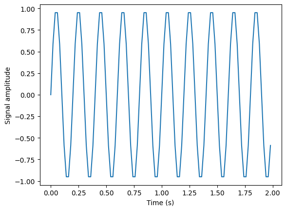

```python
%matplotlib inline
from matplotlib import pyplot as plt
import numpy as np

# Frequency in terms of Hertz
fre  = 5
# Sample rate
fre_samp = 50
t = np.linspace(0, 2, 2 * fre_samp, endpoint = False )
a = np.sin(fre  * 2 * np.pi * t)
figure, axis = plt.subplots()
axis.plot(t, a)
axis.set_xlabel ('Time (s)')
axis.set_ylabel ('Signal amplitude')
plt.show()
```

We can see that frequency is 5 Hz and its signal repeats in 1/5 seconds – it's call as a particular time period.

Let us use this sinusoid wave with the help of DFT application

```python
from scipy import fftpack
A = fftpack.fft(a)
frequency = fftpack.fftfreq(len(a)) * fre_samp
figure, axis = plt.subplots()
axis.stem(frequency, np.abs(A))
axis.set_xlabel('Frequency in Hz')
axis.set_ylabel('Frequency Spectrum Magnitude')
axis.set_xlim(-fre_samp / 2, fre_samp/ 2)
axis.set_ylim(-5, 110)
plt.show()
```

[output not shown]

In DFT example we visualize the magnitude of the signal.

## Linear Algebra

- Linear Algebra of SciPy is an implementation of BLAS and ATLAS LAPACK libraries.
- Performance of Linear Algebra is very fast compared to BLAS and LAPACK.
- Linear algebra routine accepts two-dimensional array object and output is also a two- dimensional array.

```python
# Calculating determinant of a two-dimensional matrix
from scipy import linalg
import numpy as np
#define square matrix
two_d_array = np.array([ [4,5], [3,2] ]) # pass values to det() function
determinant = linalg.det(two_d_array)
print(determinant)
```

```
-7.0
```

```python
# inverse matrix
from scipy import linalg
a = np.array([[1,2],[3,4]])
inverse_mat = linalg.inv(a)
print(inverse_mat)
```

```
[[-2.   1. ]
 [ 1.5 -0.5]]
```

```python
# Eigenvalues and Eigenvector
from scipy import linalg
import numpy as np
#define two dimensional array
arr = np.array([[5,4],[6,3]]) #pass value into function
eg_val, eg_vect = linalg.eig(arr)  #get eigenvalues
print(eg_val) #get eigenvectors print(eg_vect)
```

```
[ 9.+0.j -1.+0.j]
```

## Interpolation Functions

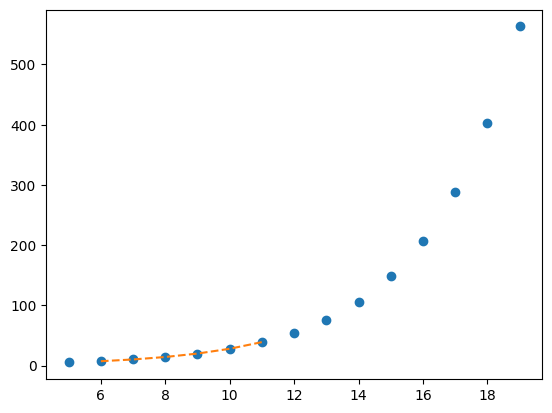

```python
import matplotlib.pyplot as plt
from scipy import interpolate
x = np.arange(5,20)
y = np.exp(x/3.0)
f = interpolate.interp1d(x, y)
x1 = np.arange(6,12)
y1 = f(x1)  # use interpolation function retruned by inter1d
plt.plot(x, y, 'o', x1, y1, '--')
plt.show()
```

## Image Processing with SciPy – scipy.ndimage

- scipy.ndimage is a submodule of SciPy which is mostly used for performing an image related operation
- ndimage means the "n" dimensional image.
- SciPy Image Processing provides Geometrics transformation (rotate, crop, flip), image filtering (sharp and de nosing), display image, image segmentation, classification and features extraction.
- MISC Package in SciPy contains prebuilt images which can be used to perform image manipulation task
- Example: Let's take a geometric transformation example of images

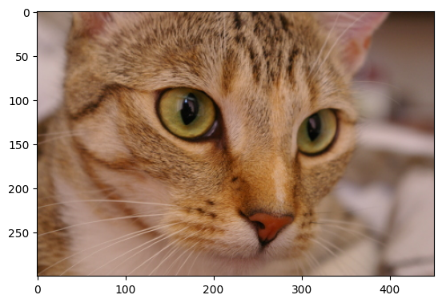

```python
from skimage import data
from matplotlib import pyplot as plt
import numpy as np
#get face image of panda from misc package
cat = data.cat()
#plot or show image of face
plt.imshow(cat)
plt.show()
```

Now we Flip-down current image:

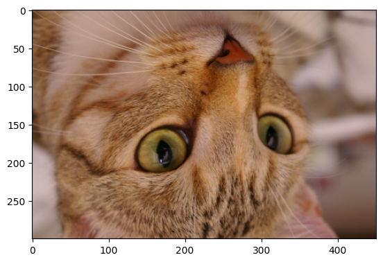

```python
#Flip Down using scipy misc.face image
flip_down = np.flipud(cat)
#flip_down = np.fliplr(misc.face())
plt.imshow(flip_down)
plt.show()
```

Example: Rotation of Image using Scipy,

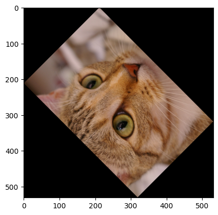

```python
from scipy import ndimage, misc
from matplotlib import pyplot as plt
cat = data.cat()
#rotatation function of scipy for image – image rotated 135 degree
panda_rotate = ndimage.rotate(cat, 135)
plt.imshow(panda_rotate)
plt.show()
```